# HW4Project

2026-02-26

Loading tidyverse, setting working directory and reading csv, as well as incorporating code from comments of last project submission to better interpret the data

```r
library(tidyverse)
setwd("C:/Users/dmd23/OneDrive - University of the Pacific")
drugs <- read_csv("drug_consumption.csv")
```

```r
CL_cols <- c("amphet", "caff", "coke", "shrooms")
drugs[CL_cols] <- lapply(drugs[CL_cols], function(x) as.integer(sub("^CL", "", x)))
map <- c("0.48246" = "Female", "-0.48246" = "Male")
drugs$gender <- map[as.character(drugs$gender)]
```

Using summary() and str() functions

```r
str(drugs)
```

```
## spc_tbl_ [1,885 × 32] (S3: spec_tbl_df/tbl_df/tbl/data.frame)
##  $ id       : num [1:1885] 1 2 3 4 5 6 7 8 9 10 ...
##  $ age      : num [1:1885] 0.4979 -0.0785 0.4979 -0.952 0.4979 ...
##  $ gender   : Named chr [1:1885] "Female" "Male" "Male" "Female" ...
##   ..- attr(*, "names")= chr [1:1885] "0.48246" "-0.48246" "-0.48246" "0.48246" ...
##  $ educ     : num [1:1885] -0.0592 1.9844 -0.0592 1.1637 1.9844 ...
##  $ country  : num [1:1885] 0.961 0.961 0.961 0.961 0.961 ...
##  $ ethnicity: num [1:1885] 0.126 -0.317 -0.317 -0.317 -0.317 ...
##  $ nscore   : num [1:1885] 0.313 -0.678 -0.467 -0.149 0.735 ...
##  $ escore   : num [1:1885] -0.575 1.939 0.805 -0.806 -1.633 ...
##  $ oscore   : num [1:1885] -0.5833 1.4353 -0.8473 -0.0193 -0.4517 ...
##  $ ascore   : num [1:1885] -0.917 0.761 -1.621 0.59 -0.302 ...
##  $ cscore   : num [1:1885] -0.00665 -0.14277 -1.0145 0.58489 1.30612 ...
##  $ impulsive: num [1:1885] -0.217 -0.711 -1.38 -1.38 -0.217 ...
##  $ ss       : num [1:1885] -1.181 -0.216 0.401 -1.181 -0.216 ...
##  $ alochol  : chr [1:1885] "CL5" "CL5" "CL6" "CL4" ...
##  $ amphet   : int [1:1885] 2 2 0 0 1 0 0 0 0 1 ...
##  $ amyl     : chr [1:1885] "CL0" "CL2" "CL0" "CL0" ...
##  $ benzos   : chr [1:1885] "CL2" "CL0" "CL0" "CL3" ...
##  $ caff     : int [1:1885] 6 6 6 5 6 6 6 6 6 6 ...
##  $ cannabis : chr [1:1885] "CL0" "CL4" "CL3" "CL2" ...
##  $ choc     : chr [1:1885] "CL5" "CL6" "CL4" "CL4" ...
##  $ coke     : int [1:1885] 0 3 0 2 0 0 0 0 0 0 ...
##  $ crack    : chr [1:1885] "CL0" "CL0" "CL0" "CL0" ...
##  $ ecstasy  : chr [1:1885] "CL0" "CL4" "CL0" "CL0" ...
##  $ heroin   : chr [1:1885] "CL0" "CL0" "CL0" "CL0" ...
##  $ ketamine : chr [1:1885] "CL0" "CL2" "CL0" "CL2" ...
##  $ legalh   : chr [1:1885] "CL0" "CL0" "CL0" "CL0" ...
##  $ lsd      : chr [1:1885] "CL0" "CL2" "CL0" "CL0" ...
##  $ meth     : chr [1:1885] "CL0" "CL3" "CL0" "CL0" ...
##  $ shrooms  : int [1:1885] 0 0 1 0 2 0 0 0 0 0 ...
##  $ nicotine : chr [1:1885] "CL2" "CL4" "CL0" "CL2" ...
##  $ semer    : chr [1:1885] "CL0" "CL0" "CL0" "CL0" ...
##  $ vsa      : chr [1:1885] "CL0" "CL0" "CL0" "CL0" ...
##  - attr(*, "spec")=
##   .. cols(
##   ..   id = col_double(),
##   ..   age = col_double(),
##   ..   gender = col_double(),
##   ..   educ = col_double(),
```

[output cut: 15 more lines]

```
##   ..   choc = col_character(),
##   ..   coke = col_character(),
##   ..   crack = col_character(),
##   ..   ecstasy = col_character(),
##   ..   heroin = col_character(),
##   ..   ketamine = col_character(),
##   ..   legalh = col_character(),
##   ..   lsd = col_character(),
##   ..   meth = col_character(),
##   ..   shrooms = col_character(),
##   ..   nicotine = col_character(),
##   ..   semer = col_character(),
##   ..   vsa = col_character()
##   .. )
##  - attr(*, "problems")=<externalptr>
```

```r
summary(drugs)
```

```
##        id              age              gender               educ
##  Min.   :   1.0   Min.   :-0.95197   Length:1885        Min.   :-2.435910
##  1st Qu.: 474.0   1st Qu.:-0.95197   Class :character   1st Qu.:-0.611130
##  Median : 946.0   Median :-0.07854   Mode  :character   Median :-0.059210
##  Mean   : 945.3   Mean   : 0.03461                      Mean   :-0.003806
##  3rd Qu.:1417.0   3rd Qu.: 0.49788                      3rd Qu.: 0.454680
##  Max.   :1888.0   Max.   : 2.59171                      Max.   : 1.984370
##     country          ethnicity           nscore               escore
##  Min.   :-0.5701   Min.   :-1.1070   Min.   :-3.4643600   Min.   :-3.2739300
##  1st Qu.:-0.5701   1st Qu.:-0.3169   1st Qu.:-0.6782500   1st Qu.:-0.6950900
##  Median : 0.9608   Median :-0.3169   Median : 0.0425700   Median : 0.0033200
##  Mean   : 0.3555   Mean   :-0.3096   Mean   : 0.0000466   Mean   :-0.0001628
##  3rd Qu.: 0.9608   3rd Qu.:-0.3169   3rd Qu.: 0.6296700   3rd Qu.: 0.6377900
##  Max.   : 0.9608   Max.   : 1.9072   Max.   : 3.2739300   Max.   : 3.2739300
##      oscore               ascore              cscore
##  Min.   :-3.2739300   Min.   :-3.464360   Min.   :-3.4643600
##  1st Qu.:-0.7172700   1st Qu.:-0.606330   1st Qu.:-0.6525300
##  Median :-0.0192800   Median :-0.017290   Median :-0.0066500
##  Mean   :-0.0005344   Mean   :-0.000245   Mean   :-0.0003861
##  3rd Qu.: 0.7233000   3rd Qu.: 0.760960   3rd Qu.: 0.5848900
##  Max.   : 2.9016100   Max.   : 3.464360   Max.   : 3.4643600
##    impulsive               ss              alochol              amphet
##  Min.   :-2.555240   Min.   :-2.078480   Length:1885        Min.   :0.000
##  1st Qu.:-0.711260   1st Qu.:-0.525930   Class :character   1st Qu.:0.000
##  Median :-0.217120   Median : 0.079870   Mode  :character   Median :0.000
##  Mean   : 0.007216   Mean   :-0.003292                      Mean   :1.341
##  3rd Qu.: 0.529750   3rd Qu.: 0.765400                      3rd Qu.:2.000
##  Max.   : 2.901610   Max.   : 1.921730                      Max.   :6.000
##      amyl              benzos               caff         cannabis
##  Length:1885        Length:1885        Min.   :0.000   Length:1885
##  Class :character   Class :character   1st Qu.:5.000   Class :character
##  Mode  :character   Mode  :character   Median :6.000   Mode  :character
##                                        Mean   :5.484
##                                        3rd Qu.:6.000
##                                        Max.   :6.000
##      choc                coke          crack             ecstasy
##  Length:1885        Min.   :0.000   Length:1885        Length:1885
##  Class :character   1st Qu.:0.000   Class :character   Class :character
##  Mode  :character   Median :0.000   Mode  :character   Mode  :character
##                     Mean   :1.161
```

[output cut: 8 more lines]

```
##
##      meth              shrooms        nicotine            semer
##  Length:1885        Min.   :0.000   Length:1885        Length:1885
##  Class :character   1st Qu.:0.000   Class :character   Class :character
##  Mode  :character   Median :0.000   Mode  :character   Mode  :character
##                     Mean   :1.187
##                     3rd Qu.:2.000
##                     Max.   :6.000
##      vsa
##  Length:1885
##  Class :character
##  Mode  :character
##
##
##
```

Variable classifications: Binary - gender Nominal - Ordinal - educ, Discrete - mushrooms, caffeine, coke, impulsive Continuous - escore, oscore

Three questions that can be answered in the dataset: 1.) Is there a correlation between level of education and usage of marijuana? 2.) Is there a correlation between age and level of alcohol consumption? 3.) Is there a difference in nscore between males who have done cocaine in the last year and females who have done cocaine in the last year?

Adding one new column for people who have high extraversion scores

```r
drugs <- mutate(drugs, escore > 0.75)
```

Updated plots using feedback from last week’s comments (we also changed the values of the “CL” when describing usage of drugs, but we did so in the beginning of this file so that it would apply to the questions before this one as well:

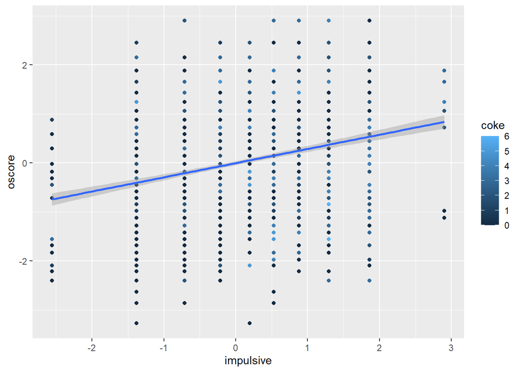

```r
ggplot(drugs, aes(impulsive, oscore, color = coke)) + geom_point() + geom_smooth(method = "lm")
```

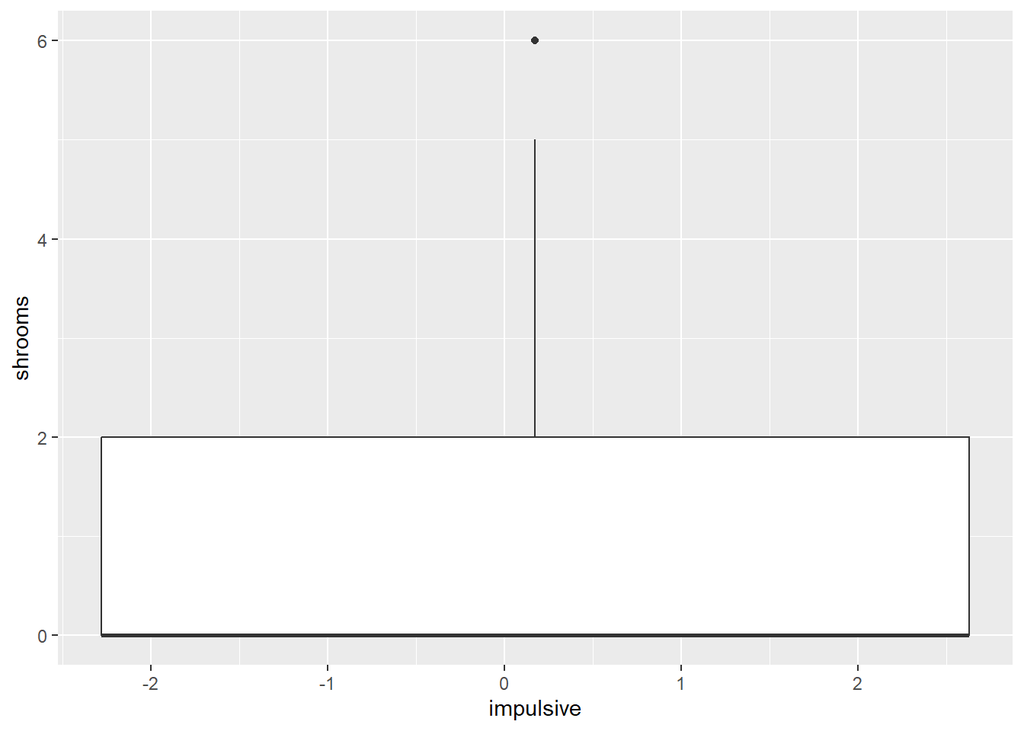

```r
ggplot(drugs, aes(impulsive, shrooms)) + geom_boxplot()
```

Summary() and Group_by() fucntions:

```r
drugs %>%
  group_by(gender) %>%
  summarize(avg_oscore = mean(oscore))
```

```
## # A tibble: 2 × 2
##   gender avg_oscore
##   <chr>       <dbl>
## 1 Female     -0.131
## 2 Male        0.130
```

Arrange() function:

```r
arrange(drugs, impulsive)
```

```
## # A tibble: 1,885 × 33
##       id     age gender    educ country ethnicity nscore escore oscore ascore
##    <dbl>   <dbl> <chr>    <dbl>   <dbl>     <dbl>  <dbl>  <dbl>  <dbl>  <dbl>
##  1    48  1.09   Male    1.16     0.961    -0.317 -2.05   0.805  0.293  0.942
##  2    72  1.09   Female -1.23     0.249    -0.317 -0.467  1.11  -0.318  1.11
##  3    77  1.09   Female -1.44     0.249    -0.317 -0.348 -0.695 -1.56   0.439
##  4    79  0.498  Male   -0.611    0.961    -0.317 -0.792 -0.806 -2.09  -1.62
##  5   138  1.09   Female  0.455    0.961    -0.317 -1.19   1.58   0.293  0.761
##  6   153 -0.0785 Female  0.455    0.961    -0.317 -0.467 -1.51  -0.717 -0.606
##  7   246 -0.0785 Female -0.611    0.961    -0.317 -0.246 -0.948 -1.68  -1.48
##  8   342  0.498  Female  1.16     0.961    -0.317 -0.467  1.11   0.883  0.288
##  9   343  1.82   Female -0.0592   0.961    -0.317 -1.69   0.962 -0.318  0.942
## 10   385  1.09   Female  0.455    0.961    -0.317  0.136 -0.300 -0.452  1.11
## # ℹ 1,875 more rows
## # ℹ 23 more variables: cscore <dbl>, impulsive <dbl>, ss <dbl>, alochol <chr>,
## #   amphet <int>, amyl <chr>, benzos <chr>, caff <int>, cannabis <chr>,
## #   choc <chr>, coke <int>, crack <chr>, ecstasy <chr>, heroin <chr>,
## #   ketamine <chr>, legalh <chr>, lsd <chr>, meth <chr>, shrooms <int>,
## #   nicotine <chr>, semer <chr>, vsa <chr>, `escore > 0.75` <lgl>
```

```r
arrange(drugs, desc(impulsive))
```

```
## # A tibble: 1,885 × 33
##       id    age gender    educ country ethnicity nscore escore  oscore  ascore
##    <dbl>  <dbl> <chr>    <dbl>   <dbl>     <dbl>  <dbl>  <dbl>   <dbl>   <dbl>
##  1   762 -0.952 Male   -0.611   -0.570    -0.317  1.72   0.322 -1.12   -0.453
##  2   862 -0.952 Female -0.611   -0.285    -0.502  1.02  -1.23   1.06   -1.08
##  3   878  0.498 Male   -0.0592  -0.570     0.114  1.23  -2.11   0.723  -1.93
##  4   901 -0.952 Female -0.611   -0.570    -0.317  1.84  -0.948 -0.976  -0.917
##  5   952 -0.952 Female -0.611   -0.570    -0.317 -1.19   0.322  1.89    0.590
##  6  1848 -0.952 Female  0.455   -0.570    -0.317  1.60  -0.948  1.24   -0.917
##  7  1861 -0.952 Male   -0.611   -0.570    -0.317  1.72   0.322  1.66   -0.155
##  8    28  0.498 Male    0.455    0.961    -0.317  0.521 -1.23  -0.0193 -0.0173
##  9    52  1.09  Male   -0.0592   0.249    -0.317  1.13   0.962 -0.583  -0.917
## 10    59  1.09  Male   -1.23     0.961    -0.317  0.224  0.638 -0.0193 -0.453
## # ℹ 1,875 more rows
## # ℹ 23 more variables: cscore <dbl>, impulsive <dbl>, ss <dbl>, alochol <chr>,
## #   amphet <int>, amyl <chr>, benzos <chr>, caff <int>, cannabis <chr>,
## #   choc <chr>, coke <int>, crack <chr>, ecstasy <chr>, heroin <chr>,
## #   ketamine <chr>, legalh <chr>, lsd <chr>, meth <chr>, shrooms <int>,
## #   nicotine <chr>, semer <chr>, vsa <chr>, `escore > 0.75` <lgl>
```

Both the first and the last row when it comes to impulsivity are relatively the same in drug consumption, with 0’s on virtually every drug usage except for chocolate

Using dplyr manipulation:

```r
drugs %>%
  filter(escore > 0.5) %>%
  group_by(gender) %>%
  summarize(mean_shrooms = mean(shrooms))
```

```
## # A tibble: 2 × 2
##   gender mean_shrooms
##   <chr>         <dbl>
## 1 Female        0.825
## 2 Male          1.80
```